# Lesson 17 - Bagging and Random Forests

### Additional Resources

- Hands-On Machine Learning, Ch 7

```python
import numpy as np
import matplotlib.pyplot as plt
import pandas as pd

from sklearn.datasets import make_classification

from sklearn.model_selection import train_test_split

from sklearn.tree import DecisionTreeClassifier
from sklearn.neighbors import KNeighborsClassifier

from ClassificationPlotter import plot_regions
```

## Generate the Data

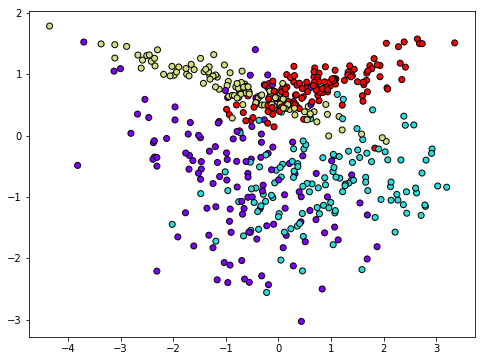

```python
np.random.seed(41)
X, y = make_classification(n_samples=500, n_classes=4, n_clusters_per_class=1,
                           n_features=2, n_redundant=0, class_sep=0.8)

plt.figure(figsize=[8,6])
plt.scatter(X[:,0], X[:,1], c=y, cmap='rainbow', edgecolor='k')
plt.show()
```

```python
X_train, X_val, y_train, y_val = train_test_split(X, y, test_size=0.2, random_state=1)
print(X_train.shape)
print(X_val.shape)
```

```
(400, 2)
(100, 2)
```

## Model 1: K-Nearest Neighbors

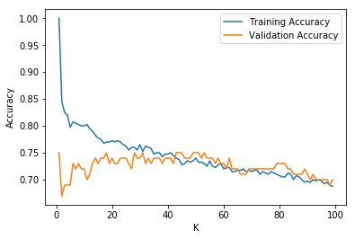

```
1
```

```python
tr_acc = []
va_acc = []
K_list = range(1,100)

for k in K_list:
    temp_mod = KNeighborsClassifier(k)
    temp_mod.fit(X_train, y_train)
    tr_acc.append(temp_mod.score(X_train, y_train))
    va_acc.append(temp_mod.score(X_val, y_val))

plt.figure(figsize=([6,4]))
plt.plot(K_list, tr_acc, label='Training Accuracy')
plt.plot(K_list, va_acc, label='Validation Accuracy')
plt.xlabel('K')
plt.ylabel('Accuracy')
plt.legend()
plt.show()

idx = np.argmax(va_acc)
best_K = K_list[idx]
print(best_K)
```

```python
knn_mod = KNeighborsClassifier(best_K)
knn_mod.fit(X_train, y_train)

print('Training Accuracy:  ', knn_mod.score(X_train, y_train))
print('Validation Accuracy:', knn_mod.score(X_val, y_val))
```

```
Training Accuracy:   1.0
Validation Accuracy: 0.75
```

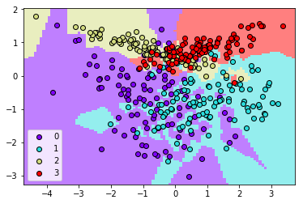

```python
plot_regions(knn_mod, X_train, y_train)
```

## Model 2: Decision Tree Model

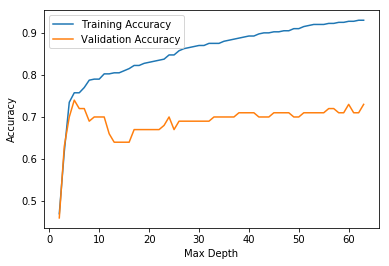

```
5
```

```python
tr_acc = []
va_acc = []
max_nodes_list = range(2,64)

np.random.seed(1)
for d in max_nodes_list:
    #temp_mod = DecisionTreeClassifier(max_depth=d)
    temp_mod = DecisionTreeClassifier(max_leaf_nodes=d)
    temp_mod.fit(X_train, y_train)
    tr_acc.append(temp_mod.score(X_train, y_train))
    va_acc.append(temp_mod.score(X_val, y_val))

plt.figure(figsize=([6,4]))
plt.plot(max_nodes_list, tr_acc, label='Training Accuracy')
plt.plot(max_nodes_list, va_acc, label='Validation Accuracy')
plt.xlabel('Max Depth')
plt.ylabel('Accuracy')
plt.legend()
plt.show()

idx = np.argmax(va_acc)
best_max = max_nodes_list[idx]
print(best_max)
```

```python
dt_mod = DecisionTreeClassifier(max_leaf_nodes=best_max)
dt_mod.fit(X_train, y_train)

print('Training Accuracy:  ', dt_mod.score(X_train, y_train))
print('Validation Accuracy:', dt_mod.score(X_val, y_val))
```

```
Training Accuracy:   0.7575
Validation Accuracy: 0.74
```

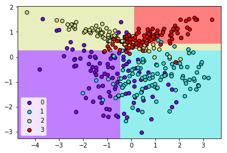

```python
plot_regions(dt_mod, X_train, y_train)
```

## Bagging and Pasting

Bagging (short for bootstrap aggregating) and pasting are two ensembling methods in which several classifiers of the same model type and specifications are trained on different sets randomly sampled from the training data. When using bagging, the sampling is performed with replacement, whereas with pasting the sampling is performed without replacement.

In practice, bagging tends to perform somewhat better than pasting, and is generally preferred.

A bagging classifier can be created by using the `BaggingClassifier` class from `sklearn`. Some parameters of interest for the bagging classifier are:

- `base_estimator` - This described the type of base classifier being used in the model.
- `n_estimators` - The number of base classifiers to use.
- `max_samples` - This is the number of training samples to use when training the base classifiers. If provided as a float, this parameter will be interpreted as a proportion.
- `bootstrap` - If `True`, then sampling is performed with replacement (Bagging). If `False`, then sampling is performed without replacement (Pasting).
- `oob_score` - If `True`, then the performance of each instance of the base classifer will be evaluated on the "out of bag" training samples that were not used to construct that model.

## Model 3: KNN Bagging Classifier

```python
from sklearn.ensemble import BaggingClassifier
```

```python
np.random.seed(1)
knn_bag_mod = BaggingClassifier(
    KNeighborsClassifier(best_K),
    n_estimators=500, max_samples=0.5,
    bootstrap=True, oob_score=True
)

knn_bag_mod.fit(X_train, y_train)

print('Out of bag score:', knn_bag_mod.oob_score_)

print('Training Accuracy:  ', knn_bag_mod.score(X_train, y_train))
print('Validation Accuracy:', knn_bag_mod.score(X_val, y_val))
```

```
Out of bag score: 0.735
Training Accuracy:   0.89
Validation Accuracy: 0.73
```

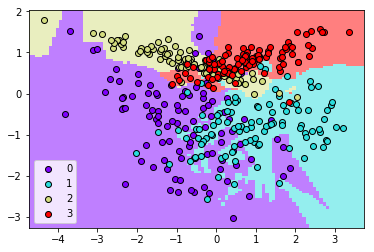

```python
plot_regions(knn_bag_mod, X_train, y_train)
```

## Model 4: Decision Tree Bagging Classifier (Random Forest)

```python
np.random.seed(1)
tree_bag_mod = BaggingClassifier(
    DecisionTreeClassifier(splitter='random', max_leaf_nodes=32),
    n_estimators=500, max_samples=0.5, bootstrap=True, oob_score = True
)

tree_bag_mod.fit(X_train, y_train)

print('Out of bag score:', tree_bag_mod.oob_score_)

print('Training Accuracy:  ', tree_bag_mod.score(X_train, y_train))
print('Validation Accuracy:', tree_bag_mod.score(X_val, y_val))
```

```
Out of bag score: 0.76
Training Accuracy:   0.8375
Validation Accuracy: 0.77
```

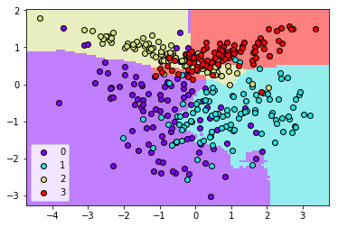

```python
plot_regions(tree_bag_mod, X_train, y_train)
```

## Model 5: Random Forest Classifier

Scikit-Learn provides a `RandomForestClassifier` class. The model created using this class is similar to what we would obtain using `BaggingClassifier` with `DecisionTreeClassifier`, but some of the parameters are fixed. For example, in `RandomForestClassifier`, we have that `splitter='random'` and `max_samples=1.0`.

```python
from sklearn.ensemble import RandomForestClassifier
```

```python
np.random.seed(1)
rf_mod = RandomForestClassifier(n_estimators=500, max_leaf_nodes=32,
                                bootstrap='True', oob_score=True)
rf_mod.fit(X_train, y_train)

print('Out of bag score:', rf_mod.oob_score_)

print('Training Accuracy:  ', rf_mod.score(X_train, y_train))
print('Validation Accuracy:', rf_mod.score(X_val, y_val))
```

```
Out of bag score: 0.7325
Training Accuracy:   0.895
Validation Accuracy: 0.74
```

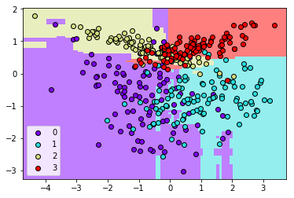

```python
plot_regions(rf_mod, X_train, y_train)
```

## Expected Proportion of In-Bag Samples

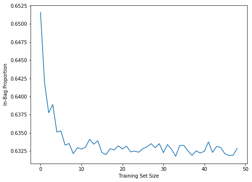

```python
in_bag_prop = []

sizes = np.arange(start=10, stop=500, step=10)

for sz in sizes:

    my_set = range(sz)

    total_of_props = 0
    for i in range(1000):
        sample = np.random.choice(my_set, size=sz, replace=True)
        n_unique = len(np.unique(sample))
        total_of_props += n_unique / sz

    avg_prop = total_of_props / 1000
    in_bag_prop.append(avg_prop)

plt.figure(figsize=[8,6])
plt.plot(in_bag_prop)
plt.xlabel('Training Set Size')
plt.ylabel('In-Bag Proportion')
plt.show()
```

## Feature Importance

```python
iris = pd.read_csv(filepath_or_buffer='Data/iris_mod.txt', sep='\t')
iris.head(n=10)
```

|  | sepal_length | sepal_width | petal_length | petal_width | species |
| --- | --- | --- | --- | --- | --- |
| 0 | 6.3 | 3.2 | 5.0 | 2.0 | virginica |
| 1 | 5.3 | 3.8 | 1.9 | 0.4 | setosa |
| 2 | 7.5 | 2.9 | 5.8 | 1.5 | virginica |
| 3 | 6.5 | 3.0 | 4.8 | 1.6 | versicolor |
| 4 | 6.8 | 3.1 | 4.9 | 1.5 | versicolor |
| 5 | 6.1 | 2.3 | 4.4 | 1.3 | versicolor |
| 6 | 4.9 | 3.5 | 1.6 | 0.4 | setosa |
| 7 | 6.3 | 3.1 | 5.7 | 1.7 | virginica |
| 8 | 4.9 | 3.5 | 1.5 | 0.2 | setosa |
| 9 | 5.5 | 3.9 | 1.3 | 0.4 | setosa |

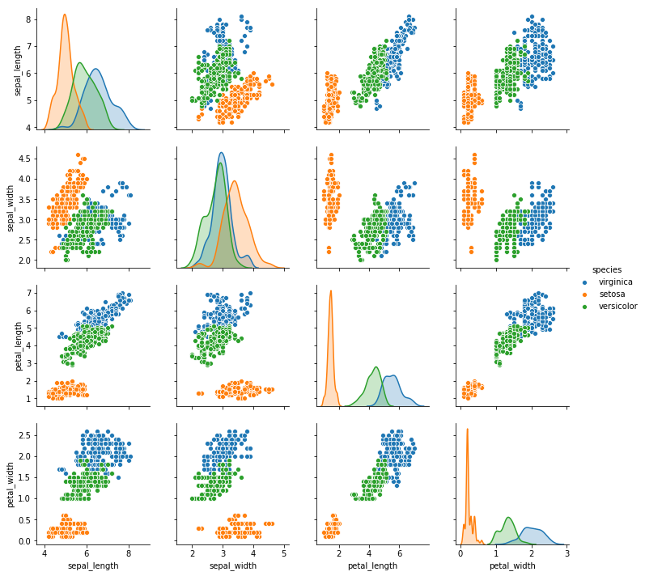

```python
import seaborn as sns

g = sns.pairplot(iris, hue="species")
plt.show()
```

```python
X_iris = iris.iloc[:,:4]
y_iris = iris.iloc[:,4]
```

```python
X_iris_train, X_iris_val, y_iris_train, y_iris_val = train_test_split(
    X_iris, y_iris, test_size=0.2, random_state=1)
```

```python
iris_forest = RandomForestClassifier(n_estimators=500, max_leaf_nodes=32,
                                bootstrap='True', oob_score=True)

iris_forest.fit(X_iris_train, y_iris_train)

print('Out of bag score:', iris_forest.oob_score_)

print('Training Accuracy:  ', iris_forest.score(X_iris_train, y_iris_train))
print('Validation Accuracy:', iris_forest.score(X_iris_train, y_iris_train))
```

```
Out of bag score: 0.98125
Training Accuracy:   1.0
Validation Accuracy: 1.0
```

```python
print(iris_forest.feature_importances_)
```

```
[0.08091799 0.0261854  0.42763723 0.46525938]
```